# R Notebook

```r
csv_file_path <- "C:\\Users\\user\\OneDrive\\Desktop\\Sem 5 Slide\\STATISTICAL MODELLING AND SIMULATION\\project assignment\\train_dataset.csv"

df <- read.csv(csv_file_path)

# Display the first few rows of the data frame
head(df)
```

|  | age | height.cm. | weight.kg. | waist.cm. | eyesight.left. | eyesight.right. | hearing.left. | hearing.right. | systolic | relaxation | fasting.blood.sugar | Cholesterol | triglyceride | HDL | LDL | hemoglobin | Urine.protein | serum.creatinine | AST | ALT | Gtp | dental.caries | smoking |
| --- | --- | --- | --- | --- | --- | --- | --- | --- | --- | --- | --- | --- | --- | --- | --- | --- | --- | --- | --- | --- | --- | --- | --- |
| 1 | 35 | 170 | 85 | 97 | 0.9 | 0.9 | 1 | 1 | 118 | 78 | 97 | 239 | 153 | 70 | 142 | 19.8 | 1 | 1.0 | 61 | 115 | 125 | 1 | 1 |
| 2 | 20 | 175 | 110 | 110 | 0.7 | 0.9 | 1 | 1 | 119 | 79 | 88 | 211 | 128 | 71 | 114 | 15.9 | 1 | 1.1 | 19 | 25 | 30 | 1 | 0 |
| 3 | 45 | 155 | 65 | 86 | 0.9 | 0.9 | 1 | 1 | 110 | 80 | 80 | 193 | 120 | 57 | 112 | 13.7 | 3 | 0.6 | 1090 | 1400 | 276 | 0 | 0 |
| 4 | 45 | 165 | 80 | 94 | 0.8 | 0.7 | 1 | 1 | 158 | 88 | 249 | 210 | 366 | 46 | 91 | 16.9 | 1 | 0.9 | 32 | 36 | 36 | 0 | 0 |
| 5 | 20 | 165 | 60 | 81 | 1.5 | 0.1 | 1 | 1 | 109 | 64 | 100 | 179 | 200 | 47 | 92 | 14.9 | 1 | 1.2 | 26 | 28 | 15 | 0 | 0 |
| 6 | 60 | 160 | 50 | 78 | 1.0 | 0.9 | 2 | 2 | 126 | 75 | 114 | 177 | 74 | 98 | 64 | 13.9 | 1 | 1.0 | 47 | 23 | 70 | 0 | 1 |

```r
#get column names
names(df)
```

```
 [1] "age"                 "height.cm."          "weight.kg."          "waist.cm."           "eyesight.left."
 [6] "eyesight.right."     "hearing.left."       "hearing.right."      "systolic"            "relaxation"
[11] "fasting.blood.sugar" "Cholesterol"         "triglyceride"        "HDL"                 "LDL"
[16] "hemoglobin"          "Urine.protein"       "serum.creatinine"    "AST"                 "ALT"
[21] "Gtp"                 "dental.caries"       "smoking"
```

```r
#check if any null value
sum(is.na(df))
```

```
[1] 0
```

```r
#Check if any duplicated data
sum(duplicated(df))
```

```
[1] 5517
```

```r
duplicated_rows <- df[duplicated(df),]
duplicated_rows
```

|  | age | height.cm. | weight.kg. | waist.cm. | eyesight.left. | eyesight.right. | hearing.left. | hearing.right. | systolic | relaxation | fasting.blood.sugar | Cholesterol | triglyceride | HDL | LDL | hemoglobin | Urine.protein | serum.creatinine | AST | ALT | Gtp | dental.caries | smoking |
| --- | --- | --- | --- | --- | --- | --- | --- | --- | --- | --- | --- | --- | --- | --- | --- | --- | --- | --- | --- | --- | --- | --- | --- |
| 702 | 20 | 165 | 60 | 78.0 | 0.9 | 0.2 | 1 | 1 | 110 | 74 | 85 | 180 | 70 | 69 | 97 | 16.5 | 1 | 0.7 | 31 | 29 | 18 | 0 | 0 |
| 1132 | 50 | 175 | 70 | 78.5 | 1.5 | 1.0 | 1 | 1 | 111 | 73 | 98 | 220 | 122 | 37 | 159 | 14.3 | 1 | 1.0 | 28 | 24 | 42 | 0 | 1 |
| 1144 | 50 | 160 | 65 | 82.0 | 1.0 | 1.0 | 1 | 1 | 121 | 82 | 99 | 215 | 143 | 63 | 123 | 14.5 | 1 | 1.1 | 27 | 22 | 21 | 0 | 0 |
| 1233 | 45 | 155 | 45 | 68.0 | 0.2 | 0.2 | 1 | 1 | 110 | 70 | 91 | 151 | 66 | 40 | 98 | 7.1 | 1 | 0.5 | 15 | 5 | 12 | 1 | 0 |
| 1346 | 25 | 165 | 85 | 92.3 | 1.2 | 1.2 | 1 | 1 | 125 | 76 | 91 | 164 | 182 | 48 | 79 | 15.5 | 1 | 0.7 | 26 | 45 | 33 | 0 | 0 |
| 1463 | 40 | 165 | 65 | 80.0 | 1.0 | 1.2 | 1 | 1 | 116 | 81 | 101 | 216 | 132 | 45 | 144 | 15.7 | 1 | 1.1 | 29 | 42 | 56 | 0 | 1 |
| 1485 | 45 | 155 | 60 | 75.0 | 1.0 | 1.0 | 1 | 1 | 113 | 67 | 88 | 204 | 98 | 72 | 112 | 13.6 | 1 | 0.5 | 20 | 31 | 25 | 0 | 0 |
| 1709 | 50 | 170 | 70 | 86.0 | 0.5 | 0.5 | 1 | 1 | 120 | 76 | 112 | 188 | 292 | 43 | 87 | 15.3 | 1 | 0.8 | 27 | 11 | 60 | 0 | 1 |
| 1750 | 75 | 150 | 50 | 75.0 | 0.4 | 0.7 | 1 | 1 | 118 | 78 | 109 | 174 | 84 | 61 | 96 | 13.9 | 1 | 1.0 | 24 | 22 | 20 | 1 | 0 |
| 1785 | 40 | 165 | 60 | 75.0 | 1.2 | 0.9 | 1 | 1 | 130 | 88 | 94 | 179 | 129 | 46 | 107 | 15.9 | 1 | 0.7 | 19 | 17 | 20 | 0 | 1 |

[output cut: 990 more lines]

```r
df<-unique(df)
df
```

|  | age | height.cm. | weight.kg. | waist.cm. | eyesight.left. | eyesight.right. | hearing.left. | hearing.right. | systolic | relaxation | fasting.blood.sugar | Cholesterol | triglyceride | HDL | LDL | hemoglobin | Urine.protein | serum.creatinine | AST | ALT | Gtp | dental.caries | smoking |
| --- | --- | --- | --- | --- | --- | --- | --- | --- | --- | --- | --- | --- | --- | --- | --- | --- | --- | --- | --- | --- | --- | --- | --- |
| 1 | 35 | 170 | 85 | 97.0 | 0.9 | 0.9 | 1 | 1 | 118 | 78 | 97 | 239 | 153 | 70 | 142 | 19.8 | 1 | 1.0 | 61 | 115 | 125 | 1 | 1 |
| 2 | 20 | 175 | 110 | 110.0 | 0.7 | 0.9 | 1 | 1 | 119 | 79 | 88 | 211 | 128 | 71 | 114 | 15.9 | 1 | 1.1 | 19 | 25 | 30 | 1 | 0 |
| 3 | 45 | 155 | 65 | 86.0 | 0.9 | 0.9 | 1 | 1 | 110 | 80 | 80 | 193 | 120 | 57 | 112 | 13.7 | 3 | 0.6 | 1090 | 1400 | 276 | 0 | 0 |
| 4 | 45 | 165 | 80 | 94.0 | 0.8 | 0.7 | 1 | 1 | 158 | 88 | 249 | 210 | 366 | 46 | 91 | 16.9 | 1 | 0.9 | 32 | 36 | 36 | 0 | 0 |
| 5 | 20 | 165 | 60 | 81.0 | 1.5 | 0.1 | 1 | 1 | 109 | 64 | 100 | 179 | 200 | 47 | 92 | 14.9 | 1 | 1.2 | 26 | 28 | 15 | 0 | 0 |
| 6 | 60 | 160 | 50 | 78.0 | 1.0 | 0.9 | 2 | 2 | 126 | 75 | 114 | 177 | 74 | 98 | 64 | 13.9 | 1 | 1.0 | 47 | 23 | 70 | 0 | 1 |
| 7 | 40 | 175 | 90 | 95.0 | 0.9 | 1.0 | 1 | 1 | 130 | 88 | 90 | 207 | 331 | 39 | 102 | 16.5 | 1 | 1.0 | 19 | 22 | 19 | 0 | 0 |
| 8 | 40 | 180 | 75 | 85.0 | 1.5 | 1.5 | 1 | 1 | 110 | 60 | 100 | 170 | 62 | 58 | 99 | 14.0 | 2 | 1.4 | 29 | 20 | 32 | 1 | 1 |
| 9 | 40 | 170 | 60 | 74.0 | 1.2 | 1.5 | 1 | 1 | 89 | 57 | 83 | 178 | 69 | 60 | 104 | 12.9 | 2 | 0.7 | 17 | 17 | 14 | 0 | 0 |
| 10 | 45 | 155 | 55 | 78.0 | 0.7 | 1.0 | 1 | 1 | 114 | 81 | 96 | 184 | 177 | 41 | 107 | 13.1 | 1 | 0.6 | 22 | 15 | 56 | 0 | 0 |

[output cut: 990 more lines]

```r
#Display the list structure
str(df)
```

```
'data.frame':   33467 obs. of  23 variables:
 $ age                : int  35 20 45 45 20 60 40 40 40 45 ...
 $ height.cm.         : int  170 175 155 165 165 160 175 180 170 155 ...
 $ weight.kg.         : int  85 110 65 80 60 50 90 75 60 55 ...
 $ waist.cm.          : num  97 110 86 94 81 78 95 85 74 78 ...
 $ eyesight.left.     : num  0.9 0.7 0.9 0.8 1.5 1 0.9 1.5 1.2 0.7 ...
 $ eyesight.right.    : num  0.9 0.9 0.9 0.7 0.1 0.9 1 1.5 1.5 1 ...
 $ hearing.left.      : int  1 1 1 1 1 2 1 1 1 1 ...
 $ hearing.right.     : int  1 1 1 1 1 2 1 1 1 1 ...
 $ systolic           : int  118 119 110 158 109 126 130 110 89 114 ...
 $ relaxation         : int  78 79 80 88 64 75 88 60 57 81 ...
 $ fasting.blood.sugar: int  97 88 80 249 100 114 90 100 83 96 ...
 $ Cholesterol        : int  239 211 193 210 179 177 207 170 178 184 ...
 $ triglyceride       : int  153 128 120 366 200 74 331 62 69 177 ...
 $ HDL                : int  70 71 57 46 47 98 39 58 60 41 ...
 $ LDL                : int  142 114 112 91 92 64 102 99 104 107 ...
 $ hemoglobin         : num  19.8 15.9 13.7 16.9 14.9 13.9 16.5 14 12.9 13.1 ...
 $ Urine.protein      : int  1 1 3 1 1 1 1 2 2 1 ...
 $ serum.creatinine   : num  1 1.1 0.6 0.9 1.2 1 1 1.4 0.7 0.6 ...
 $ AST                : int  61 19 1090 32 26 47 19 29 17 22 ...
 $ ALT                : int  115 25 1400 36 28 23 22 20 17 15 ...
 $ Gtp                : int  125 30 276 36 15 70 19 32 14 56 ...
 $ dental.caries      : int  1 1 0 0 0 0 0 1 0 0 ...
 $ smoking            : int  1 0 0 0 0 1 0 1 0 0 ...
```

```r
# get number of rows and columns of data frame
dim(df)
```

```
[1] 33467    23
```

```r
# check null values in dataset
colSums(is.na(df))
```

```
                age          height.cm.          weight.kg.           waist.cm.      eyesight.left.     eyesight.right.
                  0                   0                   0                   0                   0                   0
      hearing.left.      hearing.right.            systolic          relaxation fasting.blood.sugar         Cholesterol
                  0                   0                   0                   0                   0                   0
       triglyceride                 HDL                 LDL          hemoglobin       Urine.protein    serum.creatinine
                  0                   0                   0                   0                   0                   0
                AST                 ALT                 Gtp       dental.caries             smoking
                  0                   0                   0                   0                   0
```

```r
summary(df)
```

```
      age          height.cm.      weight.kg.       waist.cm.      eyesight.left.  eyesight.right. hearing.left.
 Min.   :20.00   Min.   :130.0   Min.   : 30.00   Min.   : 51.00   Min.   :0.100   Min.   :0.10    Min.   :1.000
 1st Qu.:40.00   1st Qu.:160.0   1st Qu.: 55.00   1st Qu.: 76.00   1st Qu.:0.800   1st Qu.:0.80    1st Qu.:1.000
 Median :40.00   Median :165.0   Median : 65.00   Median : 82.00   Median :1.000   Median :1.00    Median :1.000
 Mean   :44.15   Mean   :164.7   Mean   : 65.93   Mean   : 82.08   Mean   :1.014   Mean   :1.01    Mean   :1.025
 3rd Qu.:55.00   3rd Qu.:170.0   3rd Qu.: 75.00   3rd Qu.: 88.00   3rd Qu.:1.200   3rd Qu.:1.20    3rd Qu.:1.000
 Max.   :85.00   Max.   :190.0   Max.   :135.00   Max.   :129.00   Max.   :9.900   Max.   :9.90    Max.   :2.000
 hearing.right.     systolic       relaxation     fasting.blood.sugar  Cholesterol   triglyceride        HDL
 Min.   :1.000   Min.   : 71.0   Min.   : 40.00   Min.   : 46.00      Min.   : 55   Min.   :  8.0   Min.   :  4.00
 1st Qu.:1.000   1st Qu.:112.0   1st Qu.: 70.00   1st Qu.: 89.00      1st Qu.:172   1st Qu.: 75.0   1st Qu.: 47.00
 Median :1.000   Median :120.0   Median : 76.00   Median : 96.00      Median :195   Median :108.0   Median : 55.00
 Mean   :1.026   Mean   :121.5   Mean   : 76.02   Mean   : 99.26      Mean   :197   Mean   :126.8   Mean   : 57.26
 3rd Qu.:1.000   3rd Qu.:130.0   3rd Qu.: 82.00   3rd Qu.:104.00      3rd Qu.:220   3rd Qu.:160.0   3rd Qu.: 66.00
 Max.   :2.000   Max.   :233.0   Max.   :146.00   Max.   :423.00      Max.   :445   Max.   :999.0   Max.   :359.00
      LDL           hemoglobin    Urine.protein   serum.creatinine       AST              ALT               Gtp
 Min.   :   1.0   Min.   : 4.90   Min.   :1.000   Min.   : 0.1000   Min.   :   6.0   Min.   :   1.00   Min.   :  2.00
 1st Qu.:  92.0   1st Qu.:13.60   1st Qu.:1.000   1st Qu.: 0.8000   1st Qu.:  19.0   1st Qu.:  15.00   1st Qu.: 17.00
 Median : 113.0   Median :14.80   Median :1.000   Median : 0.9000   Median :  23.0   Median :  21.00   Median : 26.00
 Mean   : 115.2   Mean   :14.62   Mean   :1.087   Mean   : 0.8865   Mean   :  26.2   Mean   :  27.14   Mean   : 39.95
 3rd Qu.: 136.0   3rd Qu.:15.70   3rd Qu.:1.000   3rd Qu.: 1.0000   3rd Qu.:  29.0   3rd Qu.:  31.00   3rd Qu.: 44.00
 Max.   :1860.0   Max.   :21.10   Max.   :6.000   Max.   :11.6000   Max.   :1090.0   Max.   :2914.00   Max.   :999.00
 dental.caries       smoking
 Min.   :0.0000   Min.   :0.0000
 1st Qu.:0.0000   1st Qu.:0.0000
 Median :0.0000   Median :0.0000
 Mean   :0.2147   Mean   :0.3663
 3rd Qu.:0.0000   3rd Qu.:1.0000
 Max.   :1.0000   Max.   :1.0000
```

#Exploratory Data Analysis (EDA)

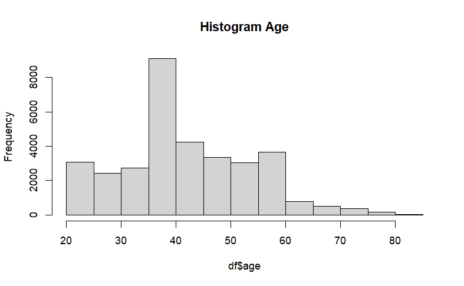

```r
hist(df$age, main = "Histogram Age")
```

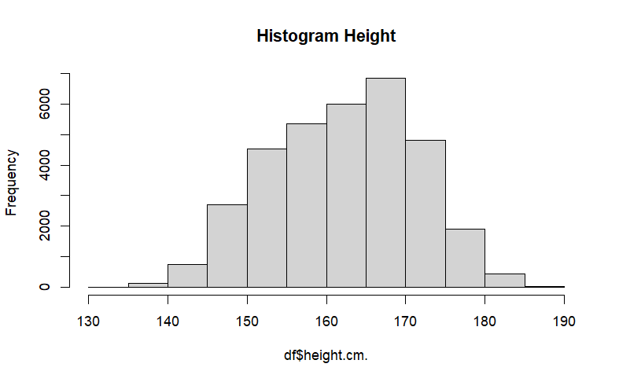

```r
hist(df$height.cm., main = "Histogram Height")
```

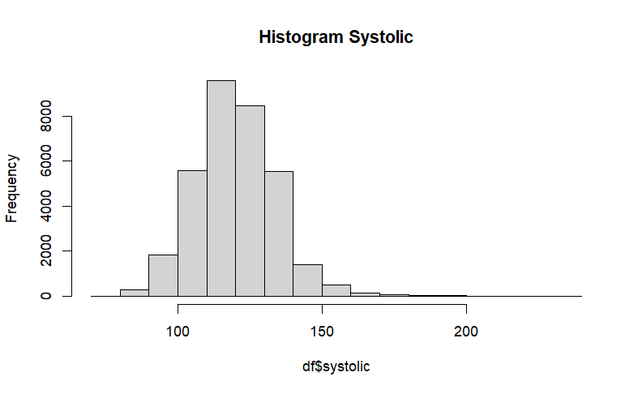

```r
hist(df$systolic, main = "Histogram Systolic")
```

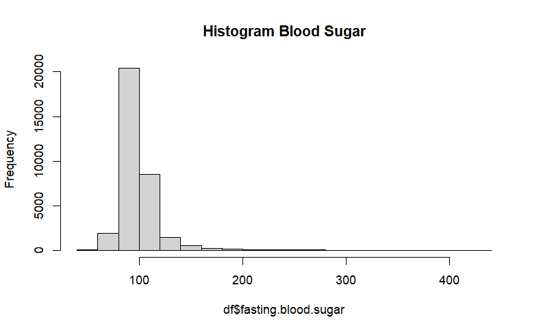

```r
hist(df$fasting.blood.sugar, main = "Histogram Blood Sugar")
```

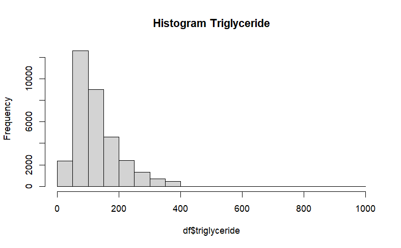

```r
hist(df$triglyceride, main = "Histogram Triglyceride")
```

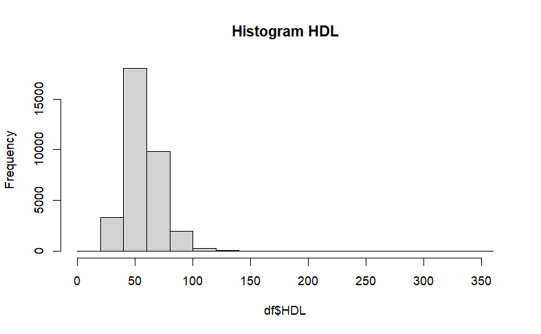

```r
hist(df$HDL, main = "Histogram HDL")
```

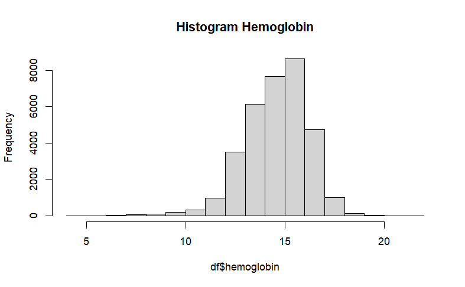

```r
hist(df$hemoglobin, main = "Histogram Hemoglobin")
```

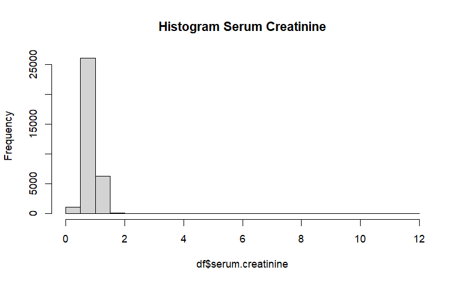

```r
hist(df$serum.creatinine, main = "Histogram Serum Creatinine")
```

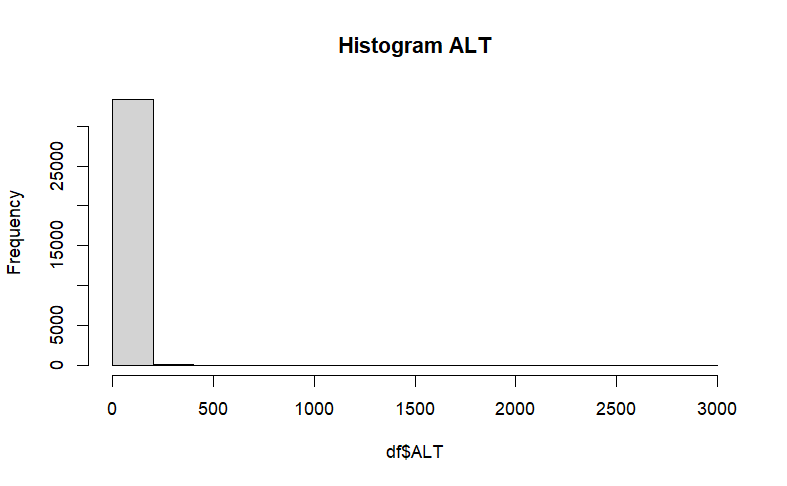

```r
hist(df$ALT, main = "Histogram ALT")
```

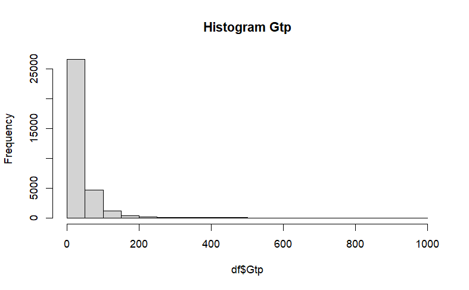

```r
hist(df$Gtp, main = "Histogram Gtp")
```

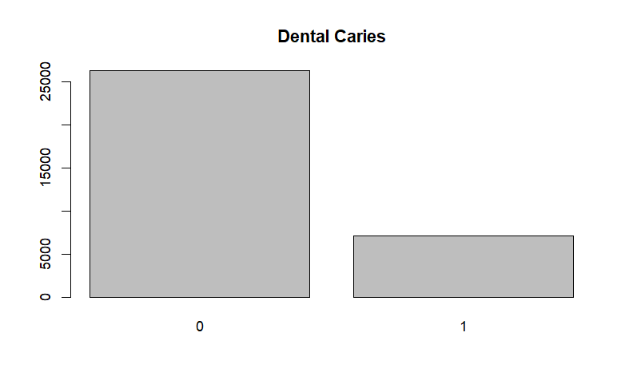

```r
barplot(table(df$dental.caries), main = "Dental Caries")
```

```r
round(cor(df),4)
```

```
                        age height.cm. weight.kg. waist.cm. eyesight.left. eyesight.right. hearing.left. hearing.right.
age                  1.0000    -0.4809    -0.3255   -0.0271        -0.1882         -0.1918        0.2018         0.2066
height.cm.          -0.4809     1.0000     0.6744    0.3781         0.1489          0.1556       -0.0808        -0.0777
weight.kg.          -0.3255     0.6744     1.0000    0.8247         0.1068          0.1136       -0.0519        -0.0526
waist.cm.           -0.0271     0.3781     0.8247    1.0000         0.0307          0.0396        0.0215         0.0197
eyesight.left.      -0.1882     0.1489     0.1068    0.0307         1.0000          0.3444       -0.0465        -0.0484
eyesight.right.     -0.1918     0.1556     0.1136    0.0396         0.3444          1.0000       -0.0374        -0.0352
hearing.left.        0.2018    -0.0808    -0.0519    0.0215        -0.0465         -0.0374        1.0000         0.5152
hearing.right.       0.2066    -0.0777    -0.0526    0.0197        -0.0484         -0.0352        0.5152         1.0000
systolic             0.1327     0.0820     0.2683    0.3193        -0.0139         -0.0083        0.0570         0.0482
relaxation           0.0484     0.1149     0.2736    0.2930         0.0072          0.0146        0.0093        -0.0012
fasting.blood.sugar  0.1833     0.0155     0.1362    0.2138        -0.0417         -0.0424        0.0421         0.0450
Cholesterol          0.0580    -0.0809     0.0254    0.0635        -0.0077         -0.0089       -0.0270        -0.0242
triglyceride         0.0147     0.1576     0.3228    0.3595         0.0225          0.0257        0.0047         0.0015
HDL                  0.0085    -0.2143    -0.3607   -0.3762        -0.0209         -0.0239       -0.0196        -0.0144
LDL                  0.0422    -0.0465     0.0368    0.0672        -0.0093         -0.0091       -0.0193        -0.0179
hemoglobin          -0.2652     0.5367     0.4888    0.3804         0.0956          0.0963       -0.0319        -0.0318
Urine.protein        0.0273     0.0060     0.0284    0.0423        -0.0088         -0.0118        0.0168         0.0179
serum.creatinine    -0.1035     0.3801     0.3175    0.2272         0.0578          0.0464        0.0022         0.0105
AST                  0.0248     0.0498     0.1289    0.1463        -0.0057         -0.0021        0.0079         0.0100
ALT                 -0.0681     0.1315     0.2513    0.2504         0.0216          0.0276        0.0004         0.0014
Gtp                  0.0113     0.1383     0.2087    0.2403         0.0029          0.0171        0.0084         0.0050
dental.caries       -0.1145     0.0829     0.0767    0.0476         0.0077          0.0169       -0.0186        -0.0165
smoking             -0.1671     0.3934     0.2981    0.2228         0.0601          0.0620       -0.0233        -0.0181
                    systolic relaxation fasting.blood.sugar Cholesterol triglyceride     HDL     LDL hemoglobin
age                   0.1327     0.0484              0.1833      0.0580       0.0147  0.0085  0.0422    -0.2652
height.cm.            0.0820     0.1149              0.0155     -0.0809       0.1576 -0.2143 -0.0465     0.5367
weight.kg.            0.2683     0.2736              0.1362      0.0254       0.3228 -0.3607  0.0368     0.4888
waist.cm.             0.3193     0.2930              0.2138      0.0635       0.3595 -0.3762  0.0672     0.3804
eyesight.left.       -0.0139     0.0072             -0.0417     -0.0077       0.0225 -0.0209 -0.0093     0.0956
eyesight.right.      -0.0083     0.0146             -0.0424     -0.0089       0.0257 -0.0239 -0.0091     0.0963
hearing.left.         0.0570     0.0093              0.0421     -0.0270       0.0047 -0.0196 -0.0193    -0.0319
hearing.right.        0.0482    -0.0012              0.0450     -0.0242       0.0015 -0.0144 -0.0179    -0.0318
systolic              1.0000     0.7606              0.1724      0.0596       0.1971 -0.0842  0.0136     0.1851
relaxation            0.7606     1.0000              0.1496      0.0947       0.2153 -0.0884  0.0358     0.2347
fasting.blood.sugar   0.1724     0.1496              1.0000      0.0091       0.2264 -0.1222 -0.0185     0.0985
Cholesterol           0.0596     0.0947              0.0091      1.0000       0.2436  0.1684  0.7066     0.0670
triglyceride          0.1971     0.2153              0.2264      0.2436       1.0000 -0.4153  0.0221     0.2724
HDL                  -0.0842    -0.0884             -0.1222      0.1684      -0.4153  1.0000 -0.0560    -0.2409
LDL                   0.0136     0.0358             -0.0185      0.7066       0.0221 -0.0560  1.0000     0.0548
```

[output cut: 17 more lines]

```
systolic                   0.0480           0.0732  0.0863  0.0935  0.1714        0.0344  0.0704
relaxation                 0.0521           0.0879  0.0865  0.1039  0.1786        0.0363  0.1045
fasting.blood.sugar        0.1055           0.0433  0.0693  0.0888  0.1801       -0.0022  0.0978
Cholesterol               -0.0012           0.0063  0.0254  0.0473  0.0835       -0.0004 -0.0296
triglyceride               0.0330           0.1234  0.1037  0.1744  0.2988        0.0296  0.2495
HDL                       -0.0085          -0.1719 -0.0362 -0.1298 -0.0480       -0.0273 -0.1774
LDL                       -0.0086           0.0319 -0.0017  0.0277 -0.0088       -0.0002 -0.0420
hemoglobin                 0.0238           0.3661  0.1239  0.1992  0.2228        0.0697  0.3983
Urine.protein              1.0000           0.0862  0.0539  0.0387  0.0706       -0.0010  0.0134
serum.creatinine           0.0862           1.0000  0.0516  0.0861  0.1112        0.0316  0.2090
AST                        0.0539           0.0516  1.0000  0.6671  0.3790        0.0131  0.0635
ALT                        0.0387           0.0861  0.6671  1.0000  0.3307        0.0259  0.0973
Gtp                        0.0706           0.1112  0.3790  0.3307  1.0000        0.0454  0.2380
dental.caries             -0.0010           0.0316  0.0131  0.0259  0.0454        1.0000  0.1064
smoking                    0.0134           0.2090  0.0635  0.0973  0.2380        0.1064  1.0000
```

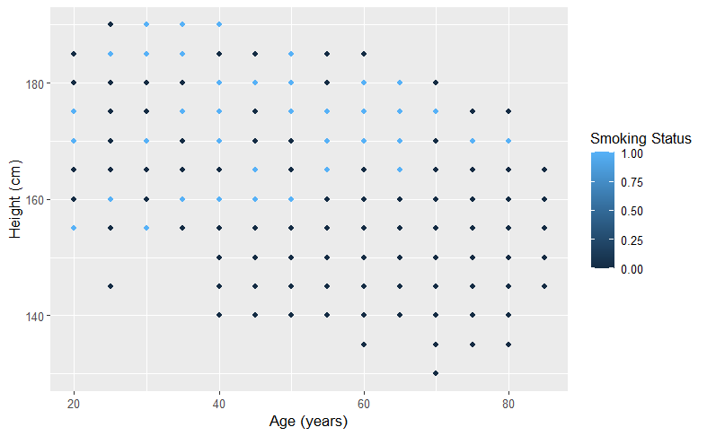

```r
#scatter plot
# Load packages
library(tidyverse)

# Load data
data(df)
# Create a scatter plot of mpg, disp, and cyl
# Create a scatter plot of age, height, and smoking
ggplot(df, aes(x = age, y = height.cm. , color = smoking)) +
  geom_point() +
  labs(x = "Age (years)", y = "Height (cm)", color = "Smoking Status")
```

Based on this scatter plot , we can see that the blue colour which represent the person is a smoker and the black colour represent the person is not a smoker. So, most of the people are not as smoker since the black dots are more than blue dots.

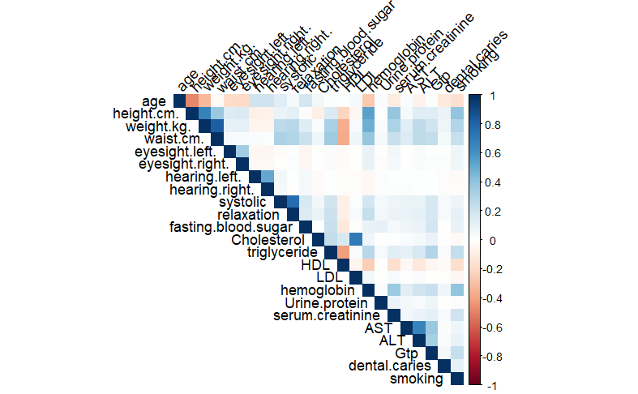

```r
# Load packages
library(tidyverse)
library(corrplot)
# Load data
data(df)
# Calculate correlation matrix
cor_mat <- cor(df)

# Plot correlation matrix
corrplot(cor_mat, method = "color", type = "upper", tl.col = "black", tl.srt = 45)
```

From the data it appears that, the box that has a color is getting very blue then, can we say it has a great correlation.

From the heatmap, there appears to be a number that shows a negative number, which means that when the number is negative, the data has a relationship that is rather than reversed. Whereas, for positive data have a relationship that is compared to straight.

If the number is approaching zero, then the more correlational it is, so in the sense of not having a relationship that can conclude.

1. Investigate the basic model obtained from the data set.

```r
logreg <- glm(formula = smoking ~ ., family = binomial(link="logit"), data = df)
summary(logreg)
```

```
Call:
glm(formula = smoking ~ ., family = binomial(link = "logit"),
    data = df)

Coefficients:
                      Estimate Std. Error z value Pr(>|z|)
(Intercept)         -1.993e+01  4.679e-01 -42.589  < 2e-16 ***
age                  8.450e-04  1.399e-03   0.604  0.54593
height.cm.           8.282e-02  2.511e-03  32.974  < 2e-16 ***
weight.kg.          -2.441e-02  2.685e-03  -9.093  < 2e-16 ***
waist.cm.            1.453e-02  3.140e-03   4.627 3.72e-06 ***
eyesight.left.       2.359e-02  2.800e-02   0.842  0.39954
eyesight.right.      1.786e-03  2.797e-02   0.064  0.94910
hearing.left.       -9.824e-02  1.030e-01  -0.954  0.34018
hearing.right.       1.169e-01  1.001e-01   1.168  0.24273
systolic            -9.436e-03  1.564e-03  -6.032 1.62e-09 ***
relaxation           4.526e-03  2.154e-03   2.102  0.03559 *
fasting.blood.sugar  4.174e-03  6.930e-04   6.024 1.71e-09 ***
Cholesterol         -5.055e-03  6.157e-04  -8.210  < 2e-16 ***
triglyceride         4.566e-03  2.476e-04  18.442  < 2e-16 ***
HDL                 -3.344e-03  1.244e-03  -2.689  0.00717 **
LDL                  2.828e-04  4.641e-04   0.609  0.54223
hemoglobin           4.400e-01  1.268e-02  34.715  < 2e-16 ***
Urine.protein       -6.612e-02  3.372e-02  -1.961  0.04988 *
serum.creatinine     1.755e-01  6.809e-02   2.578  0.00994 **
AST                 -3.490e-04  1.282e-03  -0.272  0.78549
ALT                 -6.837e-03  9.982e-04  -6.849 7.45e-12 ***
Gtp                  9.747e-03  4.346e-04  22.428  < 2e-16 ***
dental.caries        4.104e-01  3.157e-02  13.000  < 2e-16 ***
---
Signif. codes:  0 ‘***’ 0.001 ‘**’ 0.01 ‘*’ 0.05 ‘.’ 0.1 ‘ ’ 1

(Dispersion parameter for binomial family taken to be 1)

    Null deviance: 43972  on 33466  degrees of freedom
Residual deviance: 34100  on 33444  degrees of freedom
AIC: 34146

Number of Fisher Scoring iterations: 5
```

```r
 #Install and load the 'car' package (if not already installed)
 #install.packages("car")
library(car)
# Assuming 'lm_model' is your linear regression model
# Make sure your model is fitted before calculating VIF

# Calculate VIF
vif_values <- car::vif(logreg)

# Print the VIF values
print(vif_values)
```

```
                age          height.cm.          weight.kg.           waist.cm.      eyesight.left.     eyesight.right.
           1.687685            2.273006            6.248744            4.453792            1.137716            1.139278
      hearing.left.      hearing.right.            systolic          relaxation fasting.blood.sugar         Cholesterol
           1.358622            1.363709            2.447715            2.395523            1.139308            2.808775
       triglyceride                 HDL                 LDL          hemoglobin       Urine.protein    serum.creatinine
           1.766252            1.694096            2.359566            1.389577            1.022667            1.161300
                AST                 ALT                 Gtp       dental.caries
           2.275334            2.791200            1.455968            1.012046
```

```r
anova(logreg, test="Chisq")
```

```
Analysis of Deviance Table

Model: binomial, link: logit

Response: smoking

Terms added sequentially (first to last)

                    Df Deviance Resid. Df Resid. Dev  Pr(>Chi)
NULL                                33466      43972
age                  1    956.1     33465      43016 < 2.2e-16 ***
height.cm.           1   4698.2     33464      38317 < 2.2e-16 ***
weight.kg.           1     55.0     33463      38262 1.218e-13 ***
waist.cm.            1    233.9     33462      38029 < 2.2e-16 ***
eyesight.left.       1      2.2     33461      38026 0.1421187
eyesight.right.      1      0.5     33460      38026 0.4785978
hearing.left.        1      0.0     33459      38026 0.8934461
hearing.right.       1      1.0     33458      38025 0.3084187
systolic             1     11.9     33457      38013 0.0005614 ***
relaxation           1     84.9     33456      37928 < 2.2e-16 ***
fasting.blood.sugar  1    220.6     33455      37707 < 2.2e-16 ***
Cholesterol          1      2.8     33454      37705 0.0919096 .
triglyceride         1   1099.1     33453      36606 < 2.2e-16 ***
HDL                  1      5.6     33452      36600 0.0178052 *
LDL                  1      1.0     33451      36599 0.3084939
hemoglobin           1   1617.7     33450      34981 < 2.2e-16 ***
Urine.protein        1      0.6     33449      34981 0.4505911
serum.creatinine     1     11.7     33448      34969 0.0006299 ***
AST                  1      2.5     33447      34966 0.1104928
ALT                  1      6.6     33446      34960 0.0099481 **
Gtp                  1    691.0     33445      34269 < 2.2e-16 ***
dental.caries        1    168.7     33444      34100 < 2.2e-16 ***
---
Signif. codes:  0 ‘***’ 0.001 ‘**’ 0.01 ‘*’ 0.05 ‘.’ 0.1 ‘ ’ 1
```

Results & Interpretation

Significance Codes:

Variance Inflation Factors (VIF).

The Variance Inflation Factor (VIF) measures the inflation in the coefficient of the independent variable due to the collinearities among the other independent variables.

A VIF of 1 means that the regression coefficient is not inflated by the presence of the other predictors, and hence multicollinearity does not exist.

Ideally, the Variance Inflation Factors are below 5.

Results from the ANOVA test shows that “eyesight.left.”, “eyesight.right.”, “hearing.left.”, “hearing.right.”, “Cholesterol”, “LDL”, “Urine.protein”, “AST” are insignificant to the fitted model.

This is judged by the low deviance residuals as well as the Pr(>Chi) of > .05, respectively.

Hence, fit the updated glm() model (logistic regression) without the insignificant variables and non-collinear variables into logreg2.